# Scout Analysis

Francisco Souza

# Scout Analysis - Brazilian soccer championship

This is the R MarkdowDocument that bring the inicial focus on study and analyse data from payers of Brazilian soccer championship 2017.

## Getting data

After each round the scout data is avilable on cartolaFC site, a fantasy game that brings out the player performance, coach and team. To get the data, theres is a open API available https://github.com/wgenial/cartrolandofc/blob/master/nova-api.md that shows some endpoints. Unfortunately doesn’t exists an API that show the scout for each, due that, is necessary manually hit the URL https://api.cartolafc.globo.com/atletas/mercado just after the end of round to get data for each round.

Considering this scenario was necessary manually get data from site, save it on JSON format creating a list of JSON files. It means, file rodada1.json contains round 1 data and so on.

### **Defining the libraries and creating the list of files**

```r
setwd("~/Desktop/Cartola")
library("rjson")
library("stringr")

library(reshape2)
library(ggplot2)

# read all file names that contains data to be analysed
json_files <- c(list.files(path = "./Data/", pattern="*.json"))
```

### **Creating a data frame that going to receive the ‘parsed’ data.**

An important information about the data is:

#### Standart informartion for each player:

iD, nickname,clubiD,position

#### Variable information

Depending of player position and action during the game can exists an column or not. For example, if a player score a goal or not or a goalkeeper performs blocks a penality etc.

```r
listOfAtletas <- data.frame(
  atleta_id = character(),
  apelido = character(),
  clube_id = character(),
  posicao_id = character(),
  rodada_id = character(),

  pontos_num = integer(),
  preco_num = integer(),
  variacao_num = integer(),
  media_num = integer(),


  # RB - Roubada de bolas (+ 1,7)
  # G - Gol (+8,0)
  # A - Assistencia (+5,0)
  # SG - Jogos sem sofrer gols (+5,0)
  # FS - Falta sofrida ( +0,5)
  # FF - Finalizacao para fora (+0,7)
  # FD - Finalizacao defendida (+1,0)
  # FT - Finalizacao na trave (+3,5)
  # DD - Defesa dificil (+3,0)
  # DP - Defesa de penalti (+7,0)

  # GC - Gol contra (-6,0)
  # CV - Cartao vermelho (-5,0)
  # CA - Cartao amarelo (-2,0)
  # GS - Gol sofrido (-5,0)
  # PP - Penalti perdido (-3,5)
  # FC - Falta cometida (-0,5)
  # I - Impedimento (-0,5)
  # PE - Passe Errado (-0,3)
  #

  #positive
  scout_RB <- integer(),
  scout_G <- integer(),
  scout_A  <- integer(),
  scout_SG <- integer(),
  scout_FS <- integer(),
  scout_FF <- integer(),
  scout_FD <- integer(),
  scout_FT <- integer(),
  scout_DD <- integer(),
  scout_DP <- integer(),

  #negative
  scout_GC <- integer(),
  scout_CV <- integer(),
  scout_CA <- integer(),
  scout_GS <- integer(),
  scout_PP <- integer(),
  scout_FC <- integer(),
  scout_I <-integer(),
  scout_PE <-integer()
)
```

### Helper functions

Helper function to get data and parse it

```r
## Function to get JSON data file
## Return the file data
dataFromJSON <- function(file_to_read){
  rawdata<-fromJSON(file = file_to_read)
  return (rawdata)
}


## function to get the value of variable if exist
# return the value or 0
scout_var <- function(tmp_var){
  if (length(tmp_var) > 0){
    return(tmp_var)
  }else{
    return (0)
  }
}
```

```r
## iterating thru files

for (i in 1:length(json_files)){
  result <- dataFromJSON(str_replace_all(paste("./Data/",json_files[i]), pattern=" ", repl=""))

  for (i in 1:length(result$atletas)){
    tmpDF <- data.frame()
    if (length(result$atletas[[i]]$scout) > 0){
      apelido <- c(result$atletas[[i]]$apelido)

      atleta_id <- c(result$atletas[[i]]$atleta_id)
      clube_id <- c(result$atletas[[i]]$clube_id)
      posicao_id <- c(result$atletas[[i]]$posicao_id)
      rodada_id  <- c(result$atletas[[i]]$rodada_id)

      pontos_num <- (result$atletas[[i]]$pontos_num)
      preco_num <- (result$atletas[[i]]$preco_num)
      variacao_num <- (result$atletas[[i]]$variacao_num)
      media_num <- (result$atletas[[i]]$media_num)

      #positive
      scout_RB <- scout_var(result$atletas[[i]]$scout$RB)
      scout_G <- scout_var(result$atletas[[i]]$scout$G)
      scout_A  <- scout_var(result$atletas[[i]]$scout$A)
      scout_SG <- scout_var(result$atletas[[i]]$scout$SG)
      scout_FS <- scout_var(result$atletas[[i]]$scout$FS)
      scout_FF <- scout_var(result$atletas[[i]]$scout$FF)
      scout_FD <- scout_var(result$atletas[[i]]$scout$FD)
      scout_FT <- scout_var(result$atletas[[i]]$scout$FT)
      scout_DD <- scout_var(result$atletas[[i]]$scout$DD)
      scout_DP <- scout_var(result$atletas[[i]]$scout$DP)

      #negative
      scout_GC <- scout_var(result$atletas[[i]]$scout$GC)
      scout_CV <- scout_var(result$atletas[[i]]$scout$CV)
      scout_CA <- scout_var(result$atletas[[i]]$scout$CA)
      scout_GS <- scout_var(result$atletas[[i]]$scout$GS)
      scout_PP <- scout_var(result$atletas[[i]]$scout$PP)
      scout_FC <- scout_var(result$atletas[[i]]$scout$FC)
      scout_I  <- scout_var(result$atletas[[i]]$scout$I)
      scout_PE <- scout_var(result$atletas[[i]]$scout$PE)

      tmpDF <- data.frame(atleta_id, apelido,clube_id, posicao_id, rodada_id,
                          pontos_num ,
                          preco_num ,
                          variacao_num ,
                          media_num ,

                          scout_RB ,
                          scout_G ,
                          scout_A  ,
                          scout_SG ,
                          scout_FS ,
                          scout_FF ,
                          scout_FD ,
                          scout_FT ,
                          scout_DD ,
                          scout_DP ,

                          #negative
                          scout_GC ,
                          scout_CV ,
                          scout_CA ,
                          scout_GS ,
                          scout_PP ,
                          scout_FC ,
                          scout_I ,
                          scout_PE
      )
      listOfAtletas <- rbind(listOfAtletas, tmpDF)
    }
  }
}
```

## Creating a subset to analyse

Getting only player ‘Atacante’ where performed : FF- Finalizacao para fora (+0,7), FD - Finalizacao defendida (+1,0) and FT - Finalizacao na trave (+3,5)

```r
## getting a subset to test
subset_listOfAtletas <- subset(listOfAtletas,
                               select=c("atleta_id","posicao_id", "apelido", "scout_FF","scout_FD","scout_FT"),
                               posicao_id == 5 & scout_FF > 0 & scout_FD >0 & scout_FT>0)

## meaning of aggregated subset
subset_listOfAtletas_aggregated <- aggregate( subset_listOfAtletas[, 4:6],
                       by=list(subset_listOfAtletas$apelido), FUN=mean)

## ordering the subset
subset_listOfAtletas_aggregated [order(scout_FF,scout_FD,scout_FT)]
```

```
##                Group.1
## 1                 Fred
## 2         Rafael Moura
## 3               Walter
## 4  Júnior Dutra
## 5                 Luan
## 6         Edigar Junio
## 7     Henrique Almeida
## 8                 Joel
## 9            Guilherme
## 10 Wellington Paulista
## 11             Everton
## 12               Rossi
## 13             Arthur
## 14         Pedro Rocha
```

[output cut: 16 more lines]

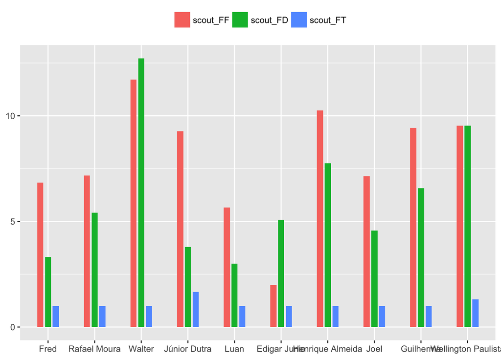

```r
## Graphic with the TOP 10 players
data.m <- melt(head(subset_listOfAtletas_aggregated, 10), id.vars='Group.1')

ggplot(data.m, aes(Group.1, value)) + geom_bar(aes(fill = variable),
   width = 0.4, position = position_dodge(width=0.5), stat="identity") +
   theme(legend.position="top", legend.title =
   element_blank(),axis.title.x=element_blank(),
   axis.title.y=element_blank())
```